# Final Task: Prediction Assignment Writeup

2023-02-05

This document is the final report of the Peer Assessment project from Coursera’s course Practical Machine Learning. It was built up in RStudio with help of rmarkdown library. This analysis is the basis for the course quiz and a prediction assignment writeup. The goal of this project is to predict the manner in which they did the exercise. This is the “classe” variable in the training set. The data for this project come from this source: http://groupware.les.inf.puc-rio.br/har.

```r
rm(list=ls())
knitr::opts_chunk$set(echo = TRUE)
set.seed(1967)
library(knitr)
library(lattice)
```

```r
library(ggplot2)
library(caret)
library(rpart)
library(rpart.plot)
library(corrplot)
library(RColorBrewer)
library(rattle)
library(randomForest)
library(data.table)
library(corrplot)
library(plotly)
library(gbm)
```

## Reading training and test datasets

The training data for this project are available here:

https://d396qusza40orc.cloudfront.net/predmachlearn/pml-training.csv

The test data are available here:

https://d396qusza40orc.cloudfront.net/predmachlearn/pml-testing.csv

The training dataset is partinioned in 2 to create a Training set (70% of the data) for the modeling process and a Test set (with the remaining 30%) for the validations.

```r
data_train <- read.csv("pml-training.csv")
data_quiz <- read.csv("pml-testing.csv")
in_train  <- createDataPartition(data_train$classe, p=0.70, list=FALSE)
train_set <- data_train[ in_train, ]
test_set  <- data_train[-in_train, ]
nzv_var <- nearZeroVar(train_set)
train_set <- train_set[ , -nzv_var]
test_set  <- test_set [ , -nzv_var]
```

## Cleaning datasets

In the dataset there is a lot of NA values, so I removed variables with more than 95% NA count. Columns 1 to 5 are identification variables only, so I removed them as well.

```r
na_var <- sapply(train_set, function(x) mean(is.na(x))) > 0.95
train_set <- train_set[ , na_var == FALSE]
test_set  <- test_set [ , na_var == FALSE]
train_set <- train_set[ , -(1:5)]
test_set  <- test_set [ , -(1:5)]
```

## Used Prediction Models

Two methods will be applied to model the regressions and the best one (with higher accuracy when applied to the Test data set) will be used for the quiz predictions. The methods are: Decision Tree and Random Forests (rf).

## Decision Tree Model

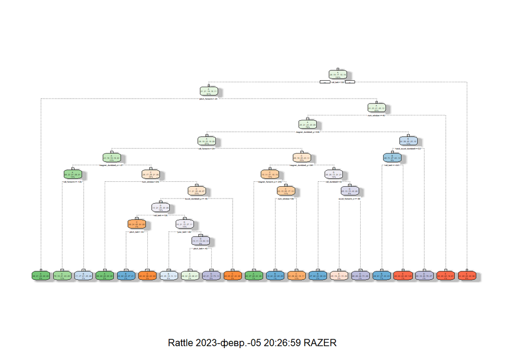

```r
set.seed(1967)
fit_DT <- rpart(classe ~ ., data = train_set, method="class")
fancyRpartPlot(fit_DT)
```

```r
predict_DT <- predict(fit_DT, newdata = test_set, type="class")
conf_matrix_DT <- confusionMatrix(table(predict_DT, test_set$classe))
conf_matrix_DT
```

```
## Confusion Matrix and Statistics
##
##
## predict_DT    A    B    C    D    E
##          A 1460  177   29   37   13
##          B  124  775   96  156   81
##          C   19   69  800  130   87
##          D   28   49   47  536   83
##          E   43   69   54  105  818
##
## Overall Statistics
##
##                Accuracy : 0.7458
##                  95% CI : (0.7345, 0.7569)
##     No Information Rate : 0.2845
##     P-Value [Acc > NIR] : < 2.2e-16
##
##                   Kappa : 0.6779
##
##  Mcnemar's Test P-Value : < 2.2e-16
##
## Statistics by Class:
##
##                      Class: A Class: B Class: C Class: D Class: E
## Sensitivity            0.8722   0.6804   0.7797  0.55602   0.7560
## Specificity            0.9392   0.9037   0.9372  0.95794   0.9436
## Pos Pred Value         0.8508   0.6291   0.7240  0.72140   0.7511
## Neg Pred Value         0.9487   0.9218   0.9527  0.91676   0.9450
## Prevalence             0.2845   0.1935   0.1743  0.16381   0.1839
## Detection Rate         0.2481   0.1317   0.1359  0.09108   0.1390
## Detection Prevalence   0.2916   0.2093   0.1878  0.12625   0.1850
## Balanced Accuracy      0.9057   0.7921   0.8585  0.75698   0.8498
```

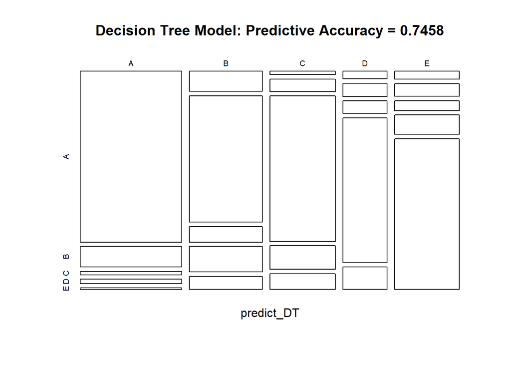

```r
plot(conf_matrix_DT$table, col = conf_matrix_DT$byClass,
     main = paste("Decision Tree Model: Predictive Accuracy =",
                  round(conf_matrix_DT$overall['Accuracy'], 4)))
```

## Random Forest Model

```r
set.seed(1967)
ctrl_RF <- trainControl(method = "repeatedcv", number = 5, repeats = 2)
fit_RF  <- train(classe ~ ., data = train_set, method = "rf",
                 trControl = ctrl_RF, verbose = FALSE)
fit_RF$finalModel
```

```
##
## Call:
##  randomForest(x = x, y = y, mtry = param$mtry, verbose = FALSE)
##                Type of random forest: classification
##                      Number of trees: 500
## No. of variables tried at each split: 27
##
##         OOB estimate of  error rate: 0.2%
## Confusion matrix:
##      A    B    C    D    E  class.error
## A 3905    0    0    0    1 0.0002560164
## B    7 2648    3    0    0 0.0037622272
## C    0    4 2391    1    0 0.0020868114
## D    0    0    4 2246    2 0.0026642984
## E    0    0    0    6 2519 0.0023762376
```

```r
predict_RF <- predict(fit_RF, newdata = test_set)
conf_matrix_RF <- confusionMatrix(table(predict_RF, test_set$classe))
conf_matrix_RF
```

```
## Confusion Matrix and Statistics
##
##
## predict_RF    A    B    C    D    E
##          A 1674    1    0    0    0
##          B    0 1137    1    0    0
##          C    0    1 1025    3    0
##          D    0    0    0  961    2
##          E    0    0    0    0 1080
##
## Overall Statistics
##
##                Accuracy : 0.9986
##                  95% CI : (0.9973, 0.9994)
##     No Information Rate : 0.2845
##     P-Value [Acc > NIR] : < 2.2e-16
##
##                   Kappa : 0.9983
##
##  Mcnemar's Test P-Value : NA
##
## Statistics by Class:
##
##                      Class: A Class: B Class: C Class: D Class: E
## Sensitivity            1.0000   0.9982   0.9990   0.9969   0.9982
## Specificity            0.9998   0.9998   0.9992   0.9996   1.0000
## Pos Pred Value         0.9994   0.9991   0.9961   0.9979   1.0000
## Neg Pred Value         1.0000   0.9996   0.9998   0.9994   0.9996
## Prevalence             0.2845   0.1935   0.1743   0.1638   0.1839
## Detection Rate         0.2845   0.1932   0.1742   0.1633   0.1835
## Detection Prevalence   0.2846   0.1934   0.1749   0.1636   0.1835
## Balanced Accuracy      0.9999   0.9990   0.9991   0.9982   0.9991
```

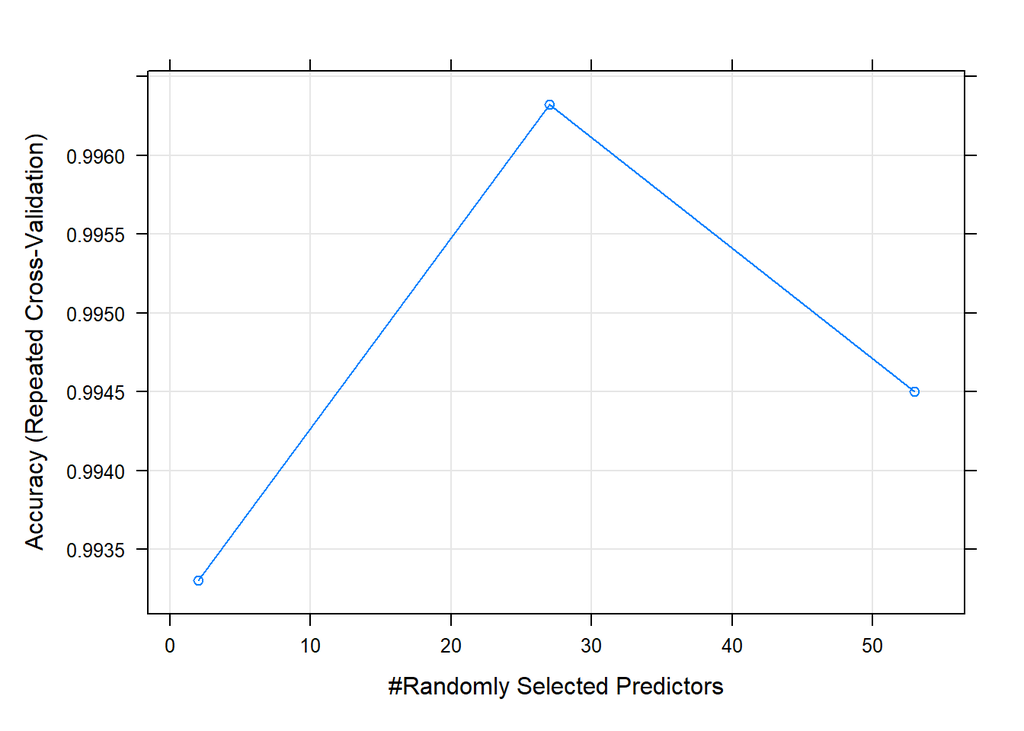

```r
plot(fit_RF)
```

```r
print(fit_RF$bestTune)
```

```
##   mtry
## 2   27
```

## Result

The predictive accuracy of the Random Forest model is 99.8 %, which is much larger than for the decision tree model (74.5%). So, the Random Forest model will be used for predictions.

## Predictions for testing dataset

Predictions:

```r
result <- predict(fit_RF, data_quiz)
result
```

```
##  [1] B A B A A E D B A A B C B A E E A B B B
## Levels: A B C D E
```